# A1

## 3.3 Cleaning

Filter out the low counts

```r
#remove the low count genes through count per million function in edgR package.
#We want the data that has cpm value greater than one, and also since there are
#three control and three stimulation, we want at least three counts of cpm > 1
cpms = edgeR::cpm(expr_data)
keep = rowSums(cpms > 1) >= 3
expr_data_filtered = expr_data[keep,]

#See the dim of filtered data.
dim(expr_data_filtered)
```

```
## [1] 13407     6
```

```r
#13407, way smaller than 23710 before cleaning
```

## 3.4 Mapping

Convert NCBI gene symbol to NCBI gene numbers (e.g. from LOC12345 to 12345)

```r
a <- grep("^LOC",rownames(expr_data_filtered))
genename <- rownames(expr_data_filtered[a,])
len <- length(rownames(expr_data_filtered[a,]))
for (i in 1:len){
  genename[i] <-  substring(genename[i], 4)
}
row.names(expr_data_filtered)[a] <- genename
```

Check all available marts

```r
listMarts()
```

```
##                biomart                version
## 1 ENSEMBL_MART_ENSEMBL      Ensembl Genes 109
## 2   ENSEMBL_MART_MOUSE      Mouse strains 109
## 3     ENSEMBL_MART_SNP  Ensembl Variation 109
## 4 ENSEMBL_MART_FUNCGEN Ensembl Regulation 109
```

Go with ensembl mart

```r
ensembl <- useMart("ensembl")
datasets <- listDatasets(ensembl)
```

Choose the human data set

```r
#search for human
knitr::kable(head(datasets[grep(datasets$dataset, pattern = "sapiens"),]),format = "html")
```

|  | dataset | description | version |
| --- | --- | --- | --- |
| 79 | hsapiens_gene_ensembl | Human genes (GRCh38.p13) | GRCh38.p13 |

```r
ensembl <- useDataset("hsapiens_gene_ensembl",mart=ensembl)
```

Look for the right filter

```r
biomart_human_filters <- listFilters(ensembl)
kable(biomart_human_filters[grep(biomart_human_filters$name,pattern="gene_id"),],format="html") %>%
  row_spec(3, background = "yellow")
```

|  | name | description |
| --- | --- | --- |
| 54 | ensembl_gene_id | Gene stable ID(s) [e.g. ENSG00000000003] |
| 55 | ensembl_gene_id_version | Gene stable ID(s) with version [e.g. ENSG00000000003.15] |
| 91 | entrezgene_id | NCBI gene (formerly Entrezgene) ID(s) [e.g. 1] |
| 114 | wikigene_id | WikiGene ID(s) [e.g. 1] |

Look for attribute

```r
kable(searchAttributes(mart = ensembl, 'gene_id')[1:12,] ,
      format="html") %>%
  row_spec(c(1,11), background = "yellow")
```

|  | name | description | page |
| --- | --- | --- | --- |
| 1 | ensembl_gene_id | Gene stable ID | feature_page |
| 2 | ensembl_gene_id_version | Gene stable ID version | feature_page |
| 79 | entrezgene_id | NCBI gene (formerly Entrezgene) ID | feature_page |
| 103 | wikigene_id | WikiGene ID | feature_page |
| 202 | ensembl_gene_id | Gene stable ID | structure |
| 203 | ensembl_gene_id_version | Gene stable ID version | structure |
| 242 | ensembl_gene_id | Gene stable ID | homologs |
| 243 | ensembl_gene_id_version | Gene stable ID version | homologs |
| 3018 | ensembl_gene_id | Gene stable ID | snp |
| 3019 | ensembl_gene_id_version | Gene stable ID version | snp |
| 3062 | ensembl_gene_id | Gene stable ID | snp_somatic |
| 3063 | ensembl_gene_id_version | Gene stable ID version | snp_somatic |

```r
kable(searchAttributes(mart = ensembl, 'hgnc_symb')[1:12,] ,
      format="html") %>%
  row_spec(c(1,11), background = "yellow")
```

|  | name | description | page |
| --- | --- | --- | --- |
| 63 | hgnc_symbol | HGNC symbol | feature_page |
| NA | NA | NA | NA |
| NA.1 | NA | NA | NA |
| NA.2 | NA | NA | NA |
| NA.3 | NA | NA | NA |
| NA.4 | NA | NA | NA |
| NA.5 | NA | NA | NA |
| NA.6 | NA | NA | NA |
| NA.7 | NA | NA | NA |
| NA.8 | NA | NA | NA |
| NA.9 | NA | NA | NA |
| NA.10 | NA | NA | NA |

Mapping the entrezgene_id to hgnc_id

```r
conversion_stash <- "gene_conversion.rds"
if (file.exists(conversion_stash)) {
  gene_conversion <- readRDS(conversion_stash)
} else {
  gene_conversion <- biomaRt::getBM(attributes = c("entrezgene_id", "hgnc_symbol"),
                                  filters = "entrezgene_id",
                                  values = rownames(expr_data_filtered),
                                  mart = ensembl)
  saveRDS(gene_conversion, conversion_stash)
}

#See how many gene IDs have been trasnalted to HGNC
length(gene_conversion$hgnc_symbol)
```

```
## [1] 142
```

```r
#How many gene IDs does not translate to HGNC
len - length(gene_conversion$hgnc_symbol)
```

```
## [1] 109
```

# 4. Normalization

## 4.1 Data Distribution

Boxplot

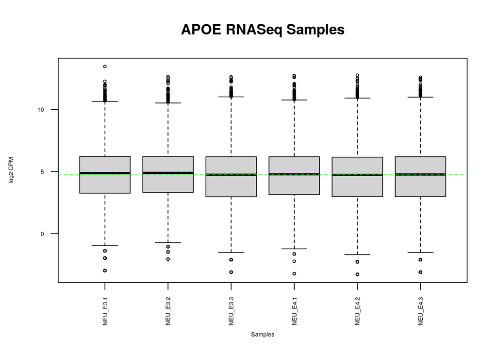

```r
data2plot <- log2(edgeR::cpm(expr_data_filtered))
boxplot(data2plot, xlab = "Samples", ylab = "log2 CPM",
        las = 2, cex = 0.5, cex.lab = 0.5,
        cex.axis = 0.5, main = "APOE RNASeq Samples")
#draw the median on each box plot
abline(h = median(apply(data2plot, 2, median)),
       col = "green", lwd = 0.6, lty = "dashed")
```

Density Plot

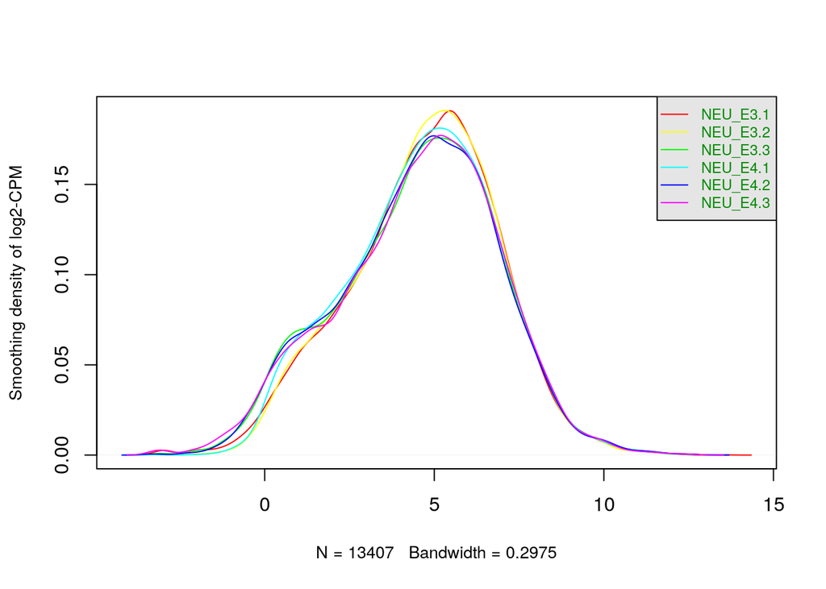

```r
counts_density <- apply(log2(edgeR::cpm(expr_data_filtered)),
                        2, density)
  #calculate the limits across all the samples
    xlim <- 0; ylim <- 0
    for (i in 1:length(counts_density)) {
      xlim <- range(c(xlim, counts_density[[i]]$x));
      ylim <- range(c(ylim, counts_density[[i]]$y))
    }
    cols <- rainbow(length(counts_density))
    ltys <- rep(1, length(counts_density))
    #plot the first density plot to initialize the plot
    plot(counts_density[[1]], xlim=xlim, ylim=ylim, type="n",
         ylab="Smoothing density of log2-CPM",
         main="", cex.lab = 0.85)
    #plot each line
    for (i in 1:length(counts_density))
      lines(counts_density[[i]], col=cols[i], lty=ltys[i])
    #create legend
    legend("topright", colnames(data2plot),
           col=cols, lty=ltys, cex=0.75,
           border ="blue",  text.col = "green4",
           merge = TRUE, bg = "gray90")
```

## 4.2 Normalize with TMM

MA plot for my data, comparing the first control neuron (NEU_E3.1) and second control neuron (NEU_E3.2). comparing the first tests neuron (NEU_E4.1) and second tests neuron (NEU_E4.2). comparing the first control neuron (NEU_E3.1) and first tests neuron (NEU_E4.1).

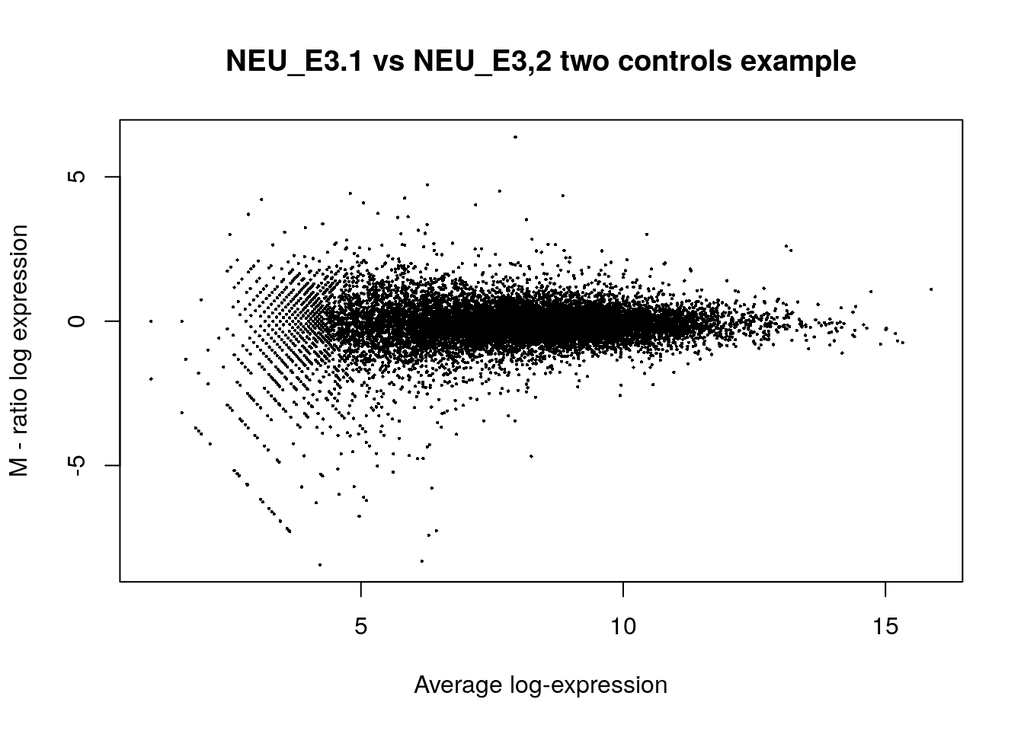

```r
plotMA(log2(expr_data_filtered[,c(1,2)]), ylab="M - ratio log expression",
       main="NEU_E3.1 vs NEU_E3,2 two controls example")
```

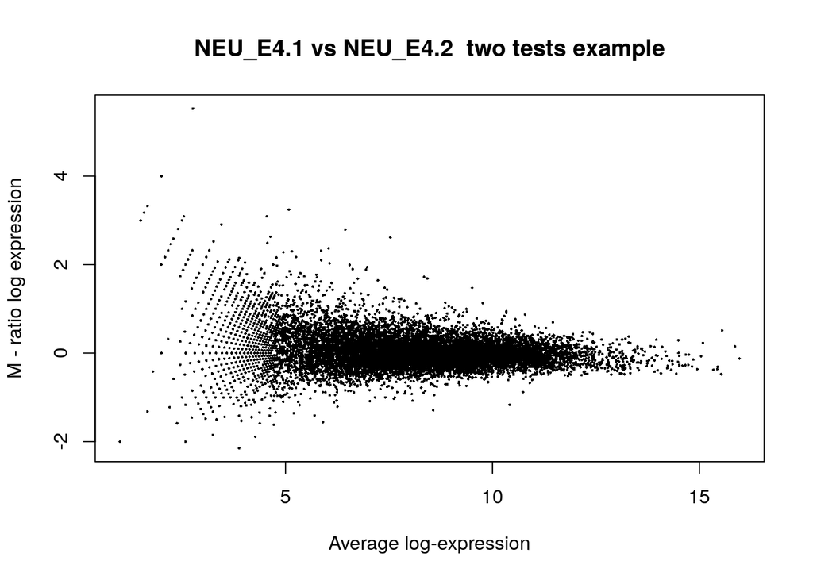

```r
plotMA(log2(expr_data_filtered[,c(4,5)]), ylab="M - ratio log expression",
       main="NEU_E4.1 vs NEU_E4.2  two tests example")
```

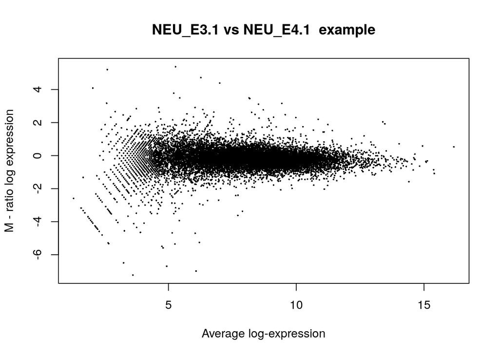

```r
plotMA(log2(expr_data_filtered[,c(1,4)]), ylab="M - ratio log expression",
       main="NEU_E3.1 vs NEU_E4.1  example")
```

Create edgerR container for RNASeq count data

```r
filtered_data_matrix <- as.matrix(expr_data_filtered)
d = edgeR::DGEList(counts=filtered_data_matrix, group=samples$cell_type)
d
```

```
## An object of class "DGEList"
## $counts
##           NEU_E3.1 NEU_E3.2 NEU_E3.3 NEU_E4.1 NEU_E4.2 NEU_E4.3
## 729737          10       10        7       14        3        6
## 643837         336      485      488      619      610      524
## 100130417       50       30       20       35       29       30
## SAMD11         757      252      227      319      226      207
## NOC2L          673      807      784      752      754      693
## 13402 more rows ...
##
## $samples
##           group lib.size norm.factors
## NEU_E3.1 NEU_E3  7865191            1
## NEU_E3.2 NEU_E3  8324929            1
## NEU_E3.3 NEU_E3  8588265            1
## NEU_E4.1 NEU_E4  9352080            1
## NEU_E4.2 NEU_E4  9678339            1
## NEU_E4.3 NEU_E4  8606620            1
```

Calculate the normolization factor

```r
d = edgeR::calcNormFactors(d)
d
```

```
## An object of class "DGEList"
## $counts
##           NEU_E3.1 NEU_E3.2 NEU_E3.3 NEU_E4.1 NEU_E4.2 NEU_E4.3
## 729737          10       10        7       14        3        6
## 643837         336      485      488      619      610      524
## 100130417       50       30       20       35       29       30
## SAMD11         757      252      227      319      226      207
## NOC2L          673      807      784      752      754      693
## 13402 more rows ...
##
## $samples
##           group lib.size norm.factors
## NEU_E3.1 NEU_E3  7865191    1.0343464
## NEU_E3.2 NEU_E3  8324929    1.0511014
## NEU_E3.3 NEU_E3  8588265    0.9801003
## NEU_E4.1 NEU_E4  9352080    0.9961664
## NEU_E4.2 NEU_E4  9678339    0.9563736
## NEU_E4.3 NEU_E4  8606620    0.9850525
```

Normalized data

```r
normalized_counts <- cpm(d)
```

Side by side box plot of original data and normalized data.

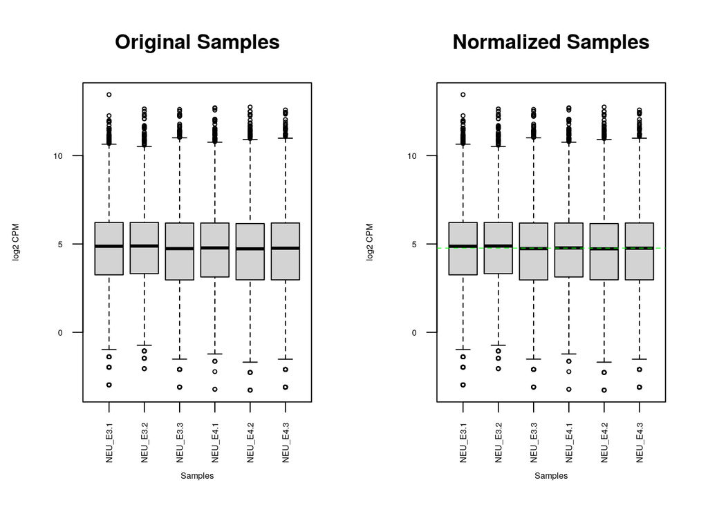

```r
data1plot <- log2(edgeR::cpm(expr_data_filtered))
data2plot <- log2(edgeR::cpm(normalized_counts))
par(mfrow = c(1, 2))
boxplot(data1plot, xlab = "Samples", ylab = "log2 CPM",
        las = 2, cex = 0.5, cex.lab = 0.5,
        cex.axis = 0.5, main = "Original Samples")
boxplot(data2plot, xlab = "Samples", ylab = "log2 CPM",
        las = 2, cex = 0.5, cex.lab = 0.5,
        cex.axis = 0.5, main = "Normalized Samples")
#draw the median on each box plot
abline(h = median(apply(data2plot, 2, median)),
       col = "green", lwd = 0.6, lty = "dashed")
```

MDS plot

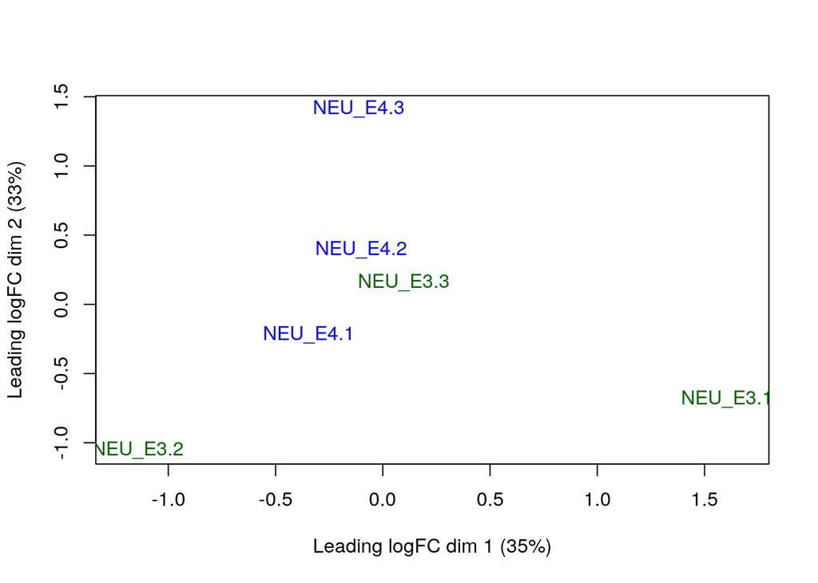

```r
plotMDS(d, labels=rownames(samples),
  col = c("darkgreen","blue")[factor(samples$cell_type)])
```

## 4.3 Diespersion

Calculate dispersion using estimateDisp fucntion.

```r
model_design <- model.matrix(~samples$cell_number
                             + samples$cell_type+0)
d <- estimateDisp(d, model_design)
```

Graphing the dispersion-squared BCV

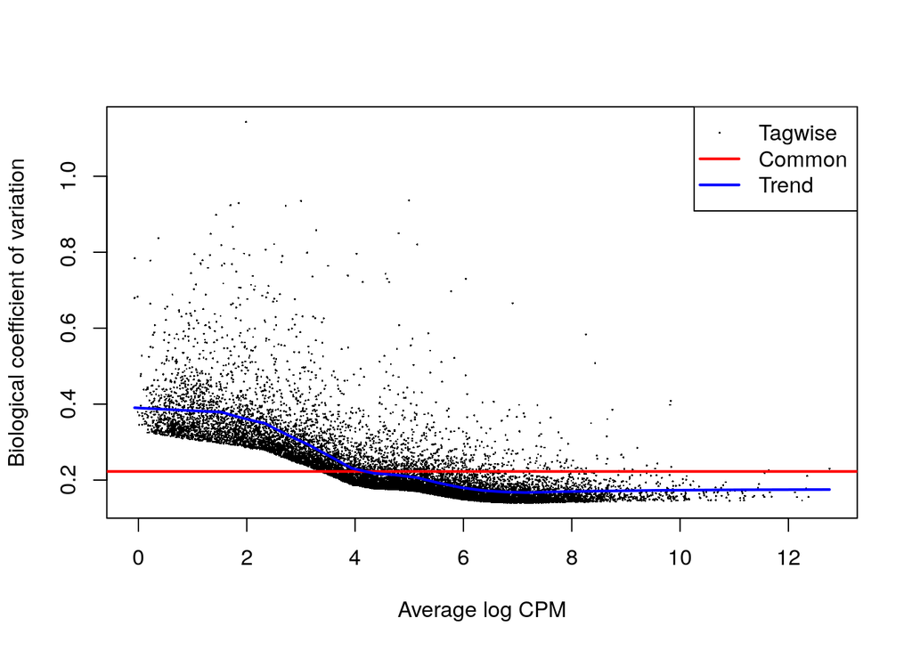

```r
plotBCV(d,col.tagwise = "black",col.common = "red",)
```

Visual representation of the mean-variance relationship

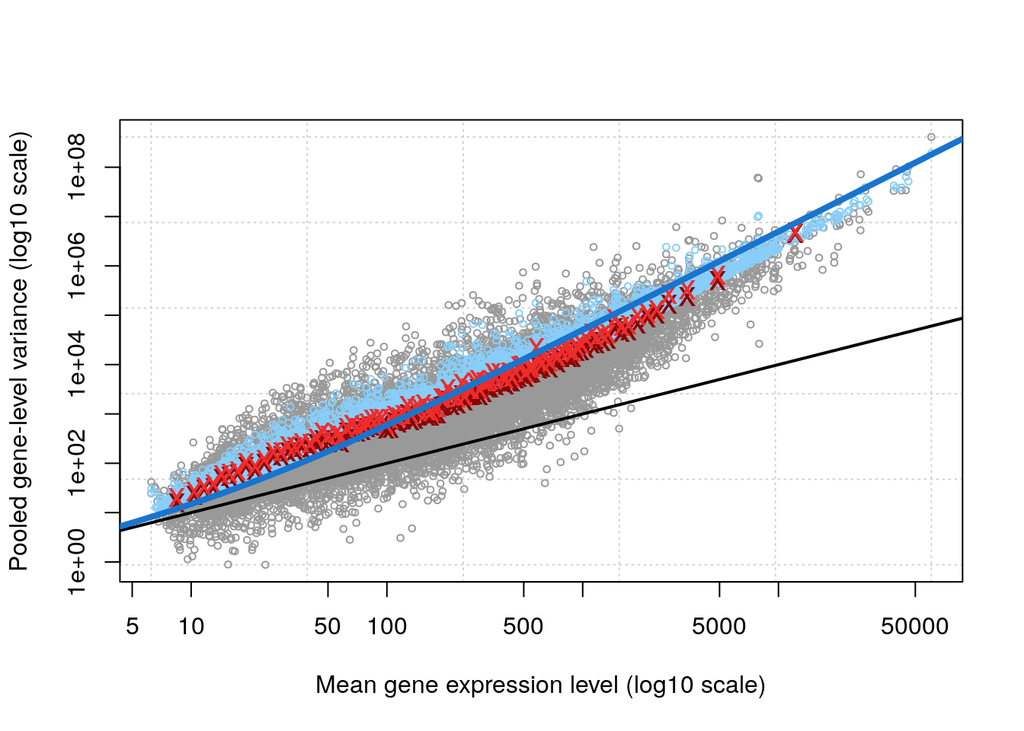

```r
edgeR::plotMeanVar(d, show.raw.vars = TRUE, show.tagwise.vars=TRUE,
            show.ave.raw.vars = TRUE,
            NBline=TRUE,
            show.binned.common.disp.vars = TRUE)
```